# Homework4

Zhang Zhixian-3210104129

We continue examining the diffusion of tetracycline among doctors in Illinois in the early 1950s, building on our work in lab 6. You will need the data sets `ckm_nodes.csv` and `ckm_network.dat` from the labs.

1. Clean the data to eliminate doctors for whom we have no adoption-date information, as in the labs. Only use this cleaned data in the rest of the assignment.

```r
ckm_nodes <- read.csv('D:/zhizhixian/Statistics-Computing-with-R/Data/ckm_nodes.csv')
ckm_network <- read.table('D:/zhizhixian/Statistics-Computing-with-R/Data/ckm_network.dat')
noinfor <- which(is.na(ckm_nodes$adoption_date))  # 去除NA数据
ckm_nodes <- ckm_nodes[-noinfor, ]
ckm_network <- ckm_network[-noinfor, -noinfor]
head(ckm_nodes)
```

```
##     city adoption_date medical_school attend_meetings medical_journals
## 1 Peoria             1     1920--1929       specialty                9
## 2 Peoria            12          1945+            none                5
## 3 Peoria             8     1935--1939         general                7
## 4 Peoria             9     1940--1944         general                6
## 5 Peoria             9     1935--1939         general                4
## 6 Peoria            10     1930--1934            none                7
##   free_time_with discuss_medicine_socially club_with_drs
## 1    non-doctors                        no            no
## 2        doctors                       yes            no
## 3        doctors                        no            no
## 4    non-doctors                        no            no
## 5    non-doctors                       yes            no
## 6          split                       yes            no
##   drs_among_three_best_friends practicing_here office_visits_per_week
## 1                            0       20+ years               101--150
## 2                            3         1- year                76--100
## 3                            2    10--20 years                76--100
## 4                            0     5--10 years                 51--75
## 5                            1    10--20 years                 51--75
## 6                            0    10--20 years               101--150
##       proximity_to_other_drs    specialty
## 1     in_building_and_office pediatrician
## 2     in_building_and_office           GP
## 3 in_building_but_not_office    internist
## 4     in_building_and_office           GP
## 5 in_building_but_not_office           GP
## 6     in_building_and_office    internist
```

```r
head(ckm_network)
```

```
##   V1 V2 V3 V4 V5 V6 V7 V8 V9 V10 V11 V12 V13 V14 V15 V16 V17 V18 V19 V20 V21
## 1  0  0  0  0  0  0  0  1  0   0   0   0   0   0   0   0   0   0   0   0   0
## 2  0  0  0  0  0  0  0  0  0   0   1   0   0   0   0   0   0   0   0   0   0
## 3  0  0  0  0  0  0  0  0  1   0   0   0   0   1   0   1   0   0   0   1   0
## 4  0  0  0  0  0  0  1  0  0   0   0   0   0   0   0   0   0   0   0   0   0
## 5  0  0  0  0  0  0  0  0  0   1   0   1   0   0   1   0   0   0   0   0   0
## 6  0  0  0  0  0  0  0  0  0   0   0   0   0   0   0   0   0   0   0   0   0
##   V22 V23 V24 V25 V26 V27 V28 V29 V30 V31 V32 V33 V34 V35 V36 V37 V38 V39 V58
## 1   0   0   0   0   0   0   0   0   0   0   0   0   0   0   0   0   0   0   1
## 2   0   0   0   0   0   0   0   0   0   0   0   0   0   0   0   0   0   0   0
## 3   0   0   0   0   0   0   0   1   0   1   0   1   0   1   0   1   0   0   0
## 4   0   0   0   0   0   0   0   0   0   0   0   1   0   0   0   0   1   0   0
## 5   0   0   0   0   0   0   0   0   0   0   0   0   0   0   0   0   0   0   0
## 6   0   0   0   0   0   0   0   1   0   1   0   0   0   0   0   0   0   0   0
##   V70 V72 V73 V74 V75 V76 V77 V78 V79 V80 V81 V82 V91 V92 V93 V94 V95 V96 V97
```

[output cut: 41 more lines]

2. Create a new data frame which records, for every doctor, for every month, whether that doctor began prescribing tetracycline that month, whether they had adopted tetracycline before that month, the number of their contacts who began prescribing strictly *before* that month, and the number of their contacts who began prescribing in that month or earlier. Explain why the dataframe should have 6 columns, and 2125 rows. Try not to use any loops.

```r
ckm_nodes_new <- data.frame(doctor=row.names(ckm_nodes)) %>% slice(rep(1:n(),each=17)) %>% mutate(month=rep(1:17,length.out=n())) %>% mutate(begin = as.numeric(ckm_nodes[doctor,2]==month)) %>% mutate(adopted_before = as.numeric(ckm_nodes[doctor,2]< month))
sum1 <- function(x){
  return(sum(ckm_nodes[ckm_network[as.numeric(x[1]),]==1,2] < as.numeric(x[2])))
}
sum2 <- function(x){
  return(sum(ckm_nodes[ckm_network[as.numeric(x[1]),]==1,2] <= as.numeric(x[2])))
}
ckm_nodes_new <- ckm_nodes_new %>% mutate(contacts_adopted_before = apply(ckm_nodes_new,1,sum1))

ckm_nodes_new <- ckm_nodes_new %>% mutate(contacts_adopted_that_or_before = apply(ckm_nodes_new,1,sum2))

head(ckm_nodes_new)
```

```
##   doctor month begin adopted_before contacts_adopted_before
## 1      1     1     1              0                       0
## 2      1     2     0              1                       1
## 3      1     3     0              1                       1
## 4      1     4     0              1                       2
## 5      1     5     0              1                       3
## 6      1     6     0              1                       3
##   contacts_adopted_that_or_before
## 1                               1
## 2                               1
## 3                               2
## 4                               3
## 5                               3
## 6                               3
```

3. Let

$$p_k=\rm{Pr(A\ doctor\ starts\
prescribing\ tetracycline\ this\ month \mid
\\
Number\ of\ doctor’s\ contacts\ prescribing\ before\ this\ month\ =
k )}$$
and
$$q_k=\rm{Pr(A\ doctor\
starts\ prescribing\ tetracycline\ this\ month \mid
\\
Number\ of\ doctor’s\ contacts\ prescribing\ this\ month\ = k
)}$$

We suppose that $p_k$ and $q_k$ are the same for all months.

1. Explain why there should be no more than 21 values of $k$ for which we can estimate $p_k$ and $q_k$ directly from the data.

```r
max(apply(ckm_network,1,sum))
```

```
## [1] 20
```

Explain: Since the maximum of k is 20, neither $p_k$ which based on the previous month number nor $q_k$ which based on this month number nedd more than 21 values of k.

2. Create a vector of estimated $p_k$ probabilities, using the data frame from (2). Plot the probabilities against the number of prior-adoptee contacts $k$.

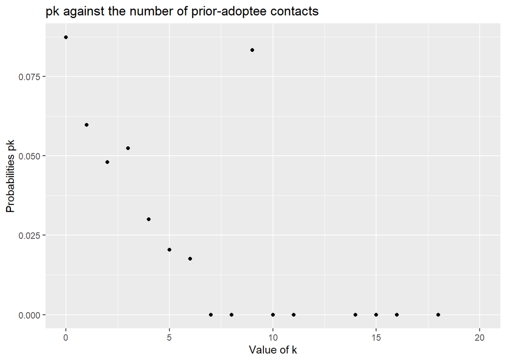

```r
total <- c()
for (k in 0:20) {
  total <- c(total,sum(na.omit(as.numeric(ckm_nodes_new[ckm_nodes_new$begin==1,]$contacts_adopted_before==k)))/sum(na.omit(as.numeric(ckm_nodes_new$contacts_adopted_before==k))))
}
# now plot it
p_k <- data.frame('pk'=total,'k'=c(0:20))
p_k %>% ggplot(aes(x=k,y=pk))+
  geom_point()+
  labs(x='Value of k',y='Probabilities pk',title='pk against the number of prior-adoptee contacts')
```

3. Create a vector of estimated $q_k$ probabilities, using the data frame from (2). Plot the probabilities against the number of prior-or-contemporary-adoptee contacts $k$.

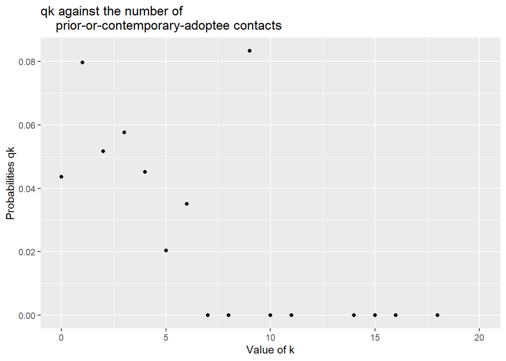

```r
total <- c()
for (k in 0:20) {
  total <- c(total,sum(na.omit(as.numeric(ckm_nodes_new[ckm_nodes_new$begin==1,]$contacts_adopted_that_or_before==k)))/sum(na.omit(as.numeric(ckm_nodes_new$contacts_adopted_before==k))))
}
# now plot it
q_k <- data.frame('qk'=total,'k'=c(0:20))
q_k %>% ggplot()+
  geom_point(aes(x=k,y=qk))+
  labs(x='Value of k',y='Probabilities qk',title='qk against the number of
    prior-or-contemporary-adoptee contacts')
```

4. Because it only conditions on information from the previous month, $p_k$ is a little easier to interpret than $q_k$. It is the probability per month that a doctor adopts tetracycline, if they have exactly $k$ contacts who had already adopted tetracycline.
1. Suppose $p_k = a + bk$. This would mean that each friend who adopts the new drug increases the probability of adoption by an equal amount. Estimate this model by least squares, using the values you constructed in (3b). Report the parameter estimates.

```r
fit_pk1 <- lm(pk~k,data=p_k)
summary(fit_pk1)
```

```
##
## Call:
## lm(formula = pk ~ k, data = p_k)
##
## Residuals:
##       Min        1Q    Median        3Q       Max
## -0.029075 -0.015700 -0.001182  0.007297  0.062074
##
## Coefficients:
##              Estimate Std. Error t value Pr(>|t|)
## (Intercept)  0.056430   0.010564   5.342 0.000104 ***
## k           -0.003908   0.001089  -3.590 0.002956 **
## ---
## Signif. codes:  0 '***' 0.001 '**' 0.01 '*' 0.05 '.' 0.1 ' ' 1
##
## Residual standard error: 0.02352 on 14 degrees of freedom
##   (因为不存在，5个观察量被删除了)
## Multiple R-squared:  0.4793, Adjusted R-squared:  0.4422
## F-statistic: 12.89 on 1 and 14 DF,  p-value: 0.002956
```

2. Suppose $p_k = e^{a+bk}/(1 + e^{a+bk})$. Explain, in words, what this model would imply about the impact of adding one more adoptee friend on a given doctor’s probability of adoption. (You can suppose that $b > 0$, if that makes it easier.) Estimate the model by least squares, using the values you constructed in (3b).

```r
fit_pk2 <- nls(pk~exp(a+b*k)/(1+exp(a+b*k)),data=p_k,start=list(a=1,b=0.5))
summary(fit_pk2)
```

```
##
## Formula: pk ~ exp(a + b * k)/(1 + exp(a + b * k))
##
## Parameters:
##   Estimate Std. Error t value Pr(>|t|)
## a -2.43067    0.21457 -11.328 1.95e-08 ***
## b -0.22725    0.07407  -3.068  0.00834 **
## ---
## Signif. codes:  0 '***' 0.001 '**' 0.01 '*' 0.05 '.' 0.1 ' ' 1
##
## Residual standard error: 0.02096 on 14 degrees of freedom
##
## Number of iterations to convergence: 8
## Achieved convergence tolerance: 9.019e-06
##   (因为不存在，5个观察量被删除了)
```

3. Plot the values from (3b) along with the estimated curves from (4a) and (4b). (You should have one plot, with $k$ on the horizontal axis, and probabilities on the vertical axis .) Which model do you prefer, and why?

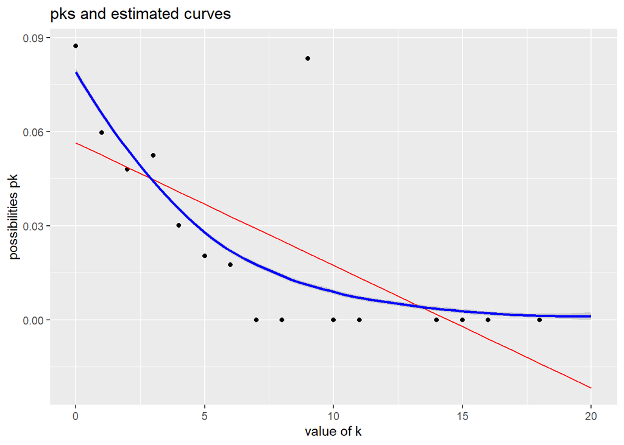

```r
y1 <- predict(fit_pk1,data.frame(k=c(0:20)))
y2 <- predict(fit_pk2,data.frame(k=c(0:20)))
p_k <- p_k %>% mutate(linear=y1) %>% mutate(nonlinear=y2)
ggplot(data = p_k)+
  geom_point(aes(x=k,y=pk))+
  geom_line(aes(x=k,y=linear),col='red')+
  geom_smooth(aes(x=k,y=nonlinear),col='blue')+
  labs(title='pks and estimated curves',
       x='value of k',
       y='possibilities pk')
```

Obviously the second one, that is, the logistic one is better.

*For quibblers, pedants, and idle hands itching for work to do*: The $p_k$ values from problem 3 aren’t all equally precise, because they come from different numbers of observations. Also, if each doctor with $k$ adoptee contacts is independently deciding whether or not to adopt with probability $p_k$, then the variance in the number of adoptees will depend on $p_k$. Say that the actual proportion who decide to adopt is $\hat{p}_k$. A little probability (exercise!) shows that in this situation, $\mathbb{E}[\hat{p}_k] = p_k$, but that $\mathrm{Var}[\hat{p}_k] = p_k(1-p_k)/n_k$, where $n_k$ is the number of doctors in that situation. (We estimate probabilities more precisely when they’re really extreme [close to 0 or 1], and/or we have lots of observations.) We can estimate that variance as $\hat{V}_k = \hat{p}_k(1-\hat{p}_k)/n_k$. Find the $\hat{V}_k$, and then re-do the estimation in (4a) and (4b) where the squared error for $p_k$ is divided by $\hat{V}_k$. How much do the parameter estimates change? How much do the plotted curves in (4c) change?

Probability exercise: Assume there are $n_k$ observations $x_1,x_2,...,x_{nk}$. And $x_i=1$ if the doctor adopts in month $k$, while $x_i=0$ on the other side. The distribution is binomial, that is $P(x_i=1)=p_k$ and $P(x_i=0)=1-p_k$, so $\mathbb{E}(x_i) = p_k$ and $\mathrm{Var}(x_i) = p_k(1-p_k)/n_k$. Thus $\mathbb{E}[\hat{p}_k] = p_k$ and $\mathrm{Var}[\hat{p}_k] = p_k(1-p_k)/n_k$

```r
p.vec <- vector(mode = "numeric",length = 21)
k.vec <- p.vec

for(k in 0:20){
  idx <- na.omit(ckm_nodes_new$contacts_adopted_before == k)
  k.vec[k+1] <- sum(idx)
  if(k.vec[k+1] == 0){
    p.vec[k+1] <- NA
    next
  }
  ckm_nodes_new_k <- ckm_nodes_new[idx,]
  p1 <- sum(ckm_nodes_new_k$begin == 1)
  p.vec[k+1] <- p1/k.vec[k+1]
}

p.vec2 <- vector(mode = "numeric",length = 21)
k.vec2 <- p.vec2
for(k in 0:20){
  idx <- na.omit((ckm_nodes_new$contacts_adopted_that_or_before - ckm_nodes_new$contacts_adopted_that_or_before) == k)
  k.vec2[k+1] <- sum(idx)
  if(k.vec2[k+1] == 0){
    p.vec2[k+1] <- NA
    next
  }
  ckm_nodes_new_k <- ckm_nodes_new[idx,]
  p1 <- sum(ckm_nodes_new_k$prescribe_that_month == 1)
  p.vec2[k+1] <- p1/k.vec2[k+1]
}
```

```r
idx <- !(is.na(p.vec) | p.vec == 0)
wt <- p.vec*(1-p.vec)/k.vec
m1 <- lm(pk ~ k, data = p_k[idx,], weight = 1/wt[idx])
m2 <- nls(pk ~ exp(a+b*k)/(1+exp(a+b*k)),data = p_k[idx,], start = list(a = 0, b = -0.2), weight = 1/wt[idx])
```

[figure not shown]

```r
w1 = predict(m1, newdata=data.frame(k=c(0:20)))
w2 = predict(m2, newdata=data.frame(k=c(0:20)))

df.w <- data.frame(k = 0:20, p = p.vec)
df.w <- mutate(df.w, linear = w1, logistic = w2)
dft <- df.w %>% gather(model, res, -k) %>% na.omit()
dft %>% ggplot() +
  geom_point(aes(x = k, y = res, color = model), size = 3) +
  geom_line(aes(x = k, y = res, color = model), size = 1) +
  labs(y = "Probability",title = "Prediction of linear and logistic models with weight")
```